# Yelp Business Rating Prediction using Tensorflow

Imports

```python
import pandas as pd
import numpy as np
import sklearn.feature_extraction.text as sk_text
from sklearn.model_selection import train_test_split
from tensorflow.keras.models import Sequential
from tensorflow.keras.layers import Dense, Activation
from tensorflow.keras.callbacks import EarlyStopping
from tensorflow.keras.callbacks import ModelCheckpoint
import io
import requests
from sklearn import metrics
from collections.abc import Sequence
from sklearn import preprocessing
import matplotlib.pyplot as plt
import shutil
import os
```

## Loaded Data, Data Pre-Processing and Clean up data

Dropped businesses with less than 20 reviews and dropped unwanted columns

```python
yelp_business_json_path = 'business.json'

df_business=pd.read_json(yelp_business_json_path,lines=True)
df_business=df_business[df_business['review_count']>19]
drop_column = ['address','city','state','postal_code','latitude','longitude','is_open','attributes','hours','review_count']
df_business=df_business.drop(drop_column,axis=1)
```

```python
df_business.head()
```

|  | business_id | name | stars | categories |
| --- | --- | --- | --- | --- |
| 0 | f9NumwFMBDn751xgFiRbNA | The Range At Lake Norman | 3.5 | Active Life, Gun/Rifle Ranges, Guns & Ammo, Sh... |
| 4 | 51M2Kk903DFYI6gnB5I6SQ | USE MY GUY SERVICES LLC | 4.5 | Home Services, Plumbing, Electricians, Handyma... |
| 5 | cKyLV5oWZJ2NudWgqs8VZw | Oasis Auto Center - Gilbert | 4.5 | Auto Repair, Automotive, Oil Change Stations, ... |
| 6 | oiAlXZPIFm2nBCt0DHLu_Q | Green World Cleaners | 3.5 | Dry Cleaning & Laundry, Local Services, Laundr... |
| 16 | uZuh51lXu7tsrC8RAwkg1A | Manolo Blahnik | 4.5 | Shopping, Shoe Stores, Fashion |

Loaded review data set and grabbed the first 500,000 reviews. Dropped unwated columns and saved as a dataframe

```python
yelp_review_json_path='review.json'
review = pd.read_json(yelp_review_json_path, lines=True,
                      dtype={'business_id':str,'stars':int,
                             'text':str},
                     chunksize=500000)
df_reviews=None
for chunk_review in review:
    chunk_review = chunk_review.drop(['review_id','user_id','useful','funny','cool','date'],axis=1)
    df_reviews=chunk_review
    break
```

Dropped any rows with null column and show the shape of the reviews dataframe

```python
df_reviews.dropna()
df_reviews.shape
```

```
(500000, 3)
```

## Merge Dataset

```python
df_combined_reviews=df_reviews.groupby('business_id')['text'].sum()
df_combined_reviews=pd.DataFrame({'business_id': df_combined_reviews.index,'all_reviews':df_combined_reviews.values})



df_combined=pd.merge(df_business,df_combined_reviews,on='business_id')
df_combined.dropna()
df_combined.head()
df_combined.to_csv('sample.csv')
```

```python
df_combined.shape
```

```
(6405, 5)
```

Extract the top 1000 most frequent words with a minimum frequency of 10.

```python
vectorizer=sk_text.CountVectorizer(min_df=10, stop_words='english',max_features=1000)
matrix=vectorizer.fit_transform(df_combined['all_reviews'])
print(vectorizer.get_feature_names())
```

```
['00', '10', '100', '11', '12', '15', '20', '24', '25', '30', '40', '45', '50', '99', 'able', 'absolutely', 'accommodating', 'actually', 'add', 'added', 'addition', 'affordable', 'afternoon', 'ago', 'ahead', 'air', 'airport', 'amazing', 'ambiance', 'american', 'apparently', 'appetizer', 'appetizers'…
```

Convert to array

```python
tfidf_data=matrix.toarray()
tfidf_data
```

```
array([[ 0,  0,  0, ...,  2,  0,  0],
       [ 0,  0,  0, ...,  0,  0,  0],
       [ 0,  0,  0, ...,  0,  0,  0],
       ...,
       [ 2, 17,  0, ...,  0,  1,  3],
       [ 0,  4,  1, ...,  0,  0,  0],
       [ 0,  0,  1, ...,  2,  0,  0]], dtype=int64)
```

```python
tfidf_data.shape
```

```
(6405, 1000)
```

## Split/Train the data

Split the data into 20% test and 80% train

```python
x_train1, x_test1, y_train1, y_test1 = train_test_split(tfidf_data, df_combined['stars'], test_size=0.2, random_state=42)
```

```python
print(x_train1.shape)
print(y_train1.shape)
print(x_test1.shape)
print(y_test1.shape)
print(tfidf_data.shape[1])
```

```
(5124, 1000)
(5124,)
(1281, 1000)
(1281,)
1000
```

## Train the Model

Tuning the different hyperparameters and taking note of the results. Different hyperparameters: Activation: relu, sigmoid,tanh Number of Dense Layers and Neurons in each Layer Optimizer: adam, sgd

```python
model = Sequential()
model.add(Dense(10, input_dim=tfidf_data.shape[1], activation='sigmoid'))
model.add(Dense(3))








model.add(Dense(1))  # 1 output neuron


model.compile(loss='mean_squared_error', optimizer='sgd')

monitor = EarlyStopping(monitor='val_loss', min_delta=1e-3, patience=5, verbose=1, mode='auto')
checkpointer = ModelCheckpoint(filepath="dnn/best_weights.hdf5", verbose=0, save_best_only=True)

model.fit(x_train1,y_train1, validation_data=(x_test1,y_test1.values),callbacks=[monitor,checkpointer],verbose=2,epochs=1000)
model.load_weights('dnn/best_weights.hdf5')
```

```
Train on 5124 samples, validate on 1281 samples
5124/5124 - 0s - loss: 0.7591 - val_loss: 0.4634
5124/5124 - 0s - loss: 0.2955 - val_loss: 0.2698
5124/5124 - 0s - loss: 0.2451 - val_loss: 0.2517
5124/5124 - 0s - loss: 0.2188 - val_loss: 0.2873
5124/5124 - 0s - loss: 0.2015 - val_loss: 0.2665
5124/5124 - 0s - loss: 0.1927 - val_loss: 0.1987
5124/5124 - 0s - loss: 0.1810 - val_loss: 0.2085
5124/5124 - 0s - loss: 0.1734 - val_loss: 0.2391
5124/5124 - 0s - loss: 0.1676 - val_loss: 0.1920
5124/5124 - 0s - loss: 0.1620 - val_loss: 0.2107
5124/5124 - 0s - loss: 0.1596 - val_loss: 0.1871
5124/5124 - 0s - loss: 0.1546 - val_loss: 0.1824
5124/5124 - 0s - loss: 0.1521 - val_loss: 0.1802
5124/5124 - 0s - loss: 0.1485 - val_loss: 0.1792
5124/5124 - 0s - loss: 0.1451 - val_loss: 0.1832
5124/5124 - 0s - loss: 0.1422 - val_loss: 0.1899
5124/5124 - 0s - loss: 0.1396 - val_loss: 0.1818
5124/5124 - 0s - loss: 0.1390 - val_loss: 0.1947
Epoch 00018: early stopping
```

## Data Results/Analysis

Using the trained model, make prediction with our testing data. Then calculate the Mean Squared Error for the model

```python
pred=model.predict(x_test1)

score=metrics.mean_squared_error(pred,y_test1)
print("Final Score (MSE):{}".format(score))
```

```
Final Score (MSE):0.1792076934272615
```

```python
score = np.sqrt(metrics.mean_squared_error(pred,y_test1))
print("Final score (RMSE): {}".format(score))
```

```
Final score (RMSE): 0.4233292966796197
```

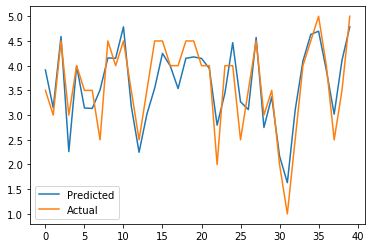

```python
plt.plot(pred[:40],label = 'Predicted')
plt.plot(y_test1[:40].values, label = 'Actual')

plt.legend()
plt.show()
```

Display the first 5 ground truth values and the predicted values

```python
df_y = pd.DataFrame(y_test1.values, columns=['ground_truth'])
df_pred = pd.DataFrame(pred, columns=['predicted'])
result = pd.concat([df_y, df_pred],axis=1)
result.head()
```

|  | ground_truth | predicted |
| --- | --- | --- |
| 0 | 3.5 | 3.911948 |
| 1 | 3.0 | 3.147778 |
| 2 | 4.5 | 4.588982 |
| 3 | 3.0 | 2.261022 |
| 4 | 4.0 | 3.990976 |

## Lift Chart

Define the helper function to print lift chart.Due to the fact that we used such a large dataset, we printed out the prediction before the expected so that the expected line can be seen better. So in this case, the expected line is orange and prediction is blue.

```python
def chart_regression(pred,y,sort=True):
    t = pd.DataFrame({'pred' : pred, 'y' : y.flatten()})
    if sort:
        t.sort_values(by=['y'],inplace=True)
    b = plt.plot(t['pred'].tolist(),label='prediction')
    a = plt.plot(t['y'].tolist(),label='expected')



    plt.ylabel('output')
    plt.legend()
    plt.show()
```

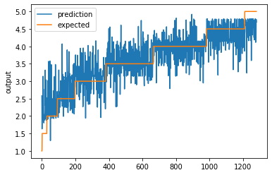

```python
chart_regression(pred.flatten(),y_test1.values,sort=True)
```

## Test Data

Chose around 5 different kind of businesses and used the model to predict the ratings of these businesses. Made our own csv with the test data and loaded it up

```python
prediction = pd.read_csv('owndata.csv')
prediction.head()
```

|  | 0 | business_id | name | all_reviews | stars |
| --- | --- | --- | --- | --- | --- |
| 0 | 1 | 11 | Barnes and Noble | Forgot how much fun a bookstore is. I could sp... | 4.0 |
| 1 | 4 | 44 | The Keg Steakhouse + Bar | Low end chain Mexican food, coupled with bad s... | 3.5 |
| 2 | 6 | 66 | Mi Mi Restaurant | Delicious delicous declicous!! It is my go-to ... | 4.0 |
| 3 | 7 | 77 | Pete's Fish Chips | Didn't care for our square fish or the sauce. ... | 2.0 |
| 4 | 8 | 88 | Taco Bell | Do not stop here if you are wanting fast food.... | 2.5 |

```python
vectorizer2=sk_text.CountVectorizer(min_df=1, stop_words='english',max_features=1000)
matrix2=vectorizer2.fit_transform(prediction['all_reviews'])
print(vectorizer2.get_feature_names())
```

```
['00', '10', '100', '15', '20', '30', '50', '60', '95', 'able', 'absolutely', 'accept', 'accompanying', 'actual', 'actually', 'adequate', 'afternoon', 'ago', 'agree', 'ahead', 'alright', 'amazing', 'amazon', 'angry', 'annoying', 'answer', 'apology', 'apparently', 'appetizer', 'area', 'aren', 'arrive…
```

Converted data to an array

```python
tfidf_data2=matrix2.toarray()
tfidf_data2.shape
```

```
(5, 1000)
```

Used our model to predict this test data

```python
pred2=model.predict(tfidf_data2)
```

Display the name of business, the actual rating and the predicted rating with our model

```python
df_name2 = pd.DataFrame(prediction['name'].values, columns=['name'])
df_y2 = pd.DataFrame(prediction['stars'].values, columns=['ground_truth'])
df_pred2 = pd.DataFrame(pred2, columns=['predicted'])
result2 = pd.concat([df_name2,df_y2, df_pred2],axis=1)
result2.head()
```

|  | name | ground_truth | predicted |
| --- | --- | --- | --- |
| 0 | Barnes and Noble | 4.0 | 2.416286 |
| 1 | The Keg Steakhouse + Bar | 3.5 | 3.453421 |
| 2 | Mi Mi Restaurant | 4.0 | 3.098944 |
| 3 | Pete's Fish Chips | 2.0 | 3.170841 |
| 4 | Taco Bell | 2.5 | 2.262947 |

It seems like our model is not as good as predicting the "extreme" ratings like 4 stars and 2 stars.